# Risk Factor Analysis

## Outcome Variable

**Outcome Variable:** y_rate_len

## Predictor Variables

**Intervention Variable:** fhtcm

**Adjustment Set:**

unadjusted

## Stratifying Variables

The analysis was stratified on these variable(s):

- agecat
- studyid
- country

## Data Summary

| agecat | studyid | country | fhtcm | n_cell | n |
| --- | --- | --- | --- | --- | --- |
| 0-3 months | ki1119695-PROBIT | BELARUS | [160-170) | 1277 | 11500 |
| 0-3 months | ki1119695-PROBIT | BELARUS | <160 | 52 | 11500 |
| 0-3 months | ki1119695-PROBIT | BELARUS | >=170 | 10171 | 11500 |
| 0-3 months | ki1101329-Keneba | GAMBIA | [160-170) | 529 | 965 |
| 0-3 months | ki1101329-Keneba | GAMBIA | <160 | 23 | 965 |
| 0-3 months | ki1101329-Keneba | GAMBIA | >=170 | 413 | 965 |
| 0-3 months | ki1135781-COHORTS | GUATEMALA | [160-170) | 88 | 180 |
| 0-3 months | ki1135781-COHORTS | GUATEMALA | <160 | 80 | 180 |
| 0-3 months | ki1135781-COHORTS | GUATEMALA | >=170 | 12 | 180 |
| 0-3 months | ki1000304b-SAS-CompFeed | INDIA | [160-170) | 412 | 716 |
| 0-3 months | ki1000304b-SAS-CompFeed | INDIA | <160 | 109 | 716 |
| 0-3 months | ki1000304b-SAS-CompFeed | INDIA | >=170 | 195 | 716 |
| 3-6 months | ki1119695-PROBIT | BELARUS | [160-170) | 1117 | 10104 |
| 3-6 months | ki1119695-PROBIT | BELARUS | <160 | 45 | 10104 |
| 3-6 months | ki1119695-PROBIT | BELARUS | >=170 | 8942 | 10104 |
| 3-6 months | ki1101329-Keneba | GAMBIA | [160-170) | 569 | 1037 |
| 3-6 months | ki1101329-Keneba | GAMBIA | <160 | 24 | 1037 |
| 3-6 months | ki1101329-Keneba | GAMBIA | >=170 | 444 | 1037 |
| 3-6 months | ki1135781-COHORTS | GUATEMALA | [160-170) | 131 | 261 |
| 3-6 months | ki1135781-COHORTS | GUATEMALA | <160 | 111 | 261 |
| 3-6 months | ki1135781-COHORTS | GUATEMALA | >=170 | 19 | 261 |
| 3-6 months | ki1000304b-SAS-CompFeed | INDIA | [160-170) | 389 | 682 |
| 3-6 months | ki1000304b-SAS-CompFeed | INDIA | <160 | 102 | 682 |
| 3-6 months | ki1000304b-SAS-CompFeed | INDIA | >=170 | 191 | 682 |
| 6-12 months | ki1119695-PROBIT | BELARUS | [160-170) | 1089 | 9870 |
| 6-12 months | ki1119695-PROBIT | BELARUS | <160 | 42 | 9870 |
| 6-12 months | ki1119695-PROBIT | BELARUS | >=170 | 8739 | 9870 |
| 6-12 months | ki1101329-Keneba | GAMBIA | [160-170) | 555 | 1005 |
| 6-12 months | ki1101329-Keneba | GAMBIA | <160 | 25 | 1005 |
| 6-12 months | ki1101329-Keneba | GAMBIA | >=170 | 425 | 1005 |
| 6-12 months | ki1135781-COHORTS | GUATEMALA | [160-170) | 164 | 329 |
| 6-12 months | ki1135781-COHORTS | GUATEMALA | <160 | 142 | 329 |
| 6-12 months | ki1135781-COHORTS | GUATEMALA | >=170 | 23 | 329 |
| 6-12 months | ki1000304b-SAS-CompFeed | INDIA | [160-170) | 387 | 679 |
| 6-12 months | ki1000304b-SAS-CompFeed | INDIA | <160 | 94 | 679 |
| 6-12 months | ki1000304b-SAS-CompFeed | INDIA | >=170 | 198 | 679 |
| 6-12 months | ki1000304b-SAS-FoodSuppl | INDIA | [160-170) | 199 | 328 |
| 6-12 months | ki1000304b-SAS-FoodSuppl | INDIA | <160 | 85 | 328 |
| 6-12 months | ki1000304b-SAS-FoodSuppl | INDIA | >=170 | 44 | 328 |
| 12-24 months | ki1119695-PROBIT | BELARUS | [160-170) | 253 | 2320 |
| 12-24 months | ki1119695-PROBIT | BELARUS | <160 | 15 | 2320 |
| 12-24 months | ki1119695-PROBIT | BELARUS | >=170 | 2052 | 2320 |
| 12-24 months | ki1101329-Keneba | GAMBIA | [160-170) | 527 | 931 |
| 12-24 months | ki1101329-Keneba | GAMBIA | <160 | 21 | 931 |
| 12-24 months | ki1101329-Keneba | GAMBIA | >=170 | 383 | 931 |
| 12-24 months | ki1135781-COHORTS | GUATEMALA | [160-170) | 206 | 421 |
| 12-24 months | ki1135781-COHORTS | GUATEMALA | <160 | 183 | 421 |
| 12-24 months | ki1135781-COHORTS | GUATEMALA | >=170 | 32 | 421 |

The following strata were considered:

- agecat: 0-3 months, studyid: ki1000304b-SAS-CompFeed, country: INDIA
- agecat: 0-3 months, studyid: ki1101329-Keneba, country: GAMBIA
- agecat: 0-3 months, studyid: ki1119695-PROBIT, country: BELARUS
- agecat: 0-3 months, studyid: ki1135781-COHORTS, country: GUATEMALA
- agecat: 12-24 months, studyid: ki1101329-Keneba, country: GAMBIA
- agecat: 12-24 months, studyid: ki1119695-PROBIT, country: BELARUS
- agecat: 12-24 months, studyid: ki1135781-COHORTS, country: GUATEMALA
- agecat: 3-6 months, studyid: ki1000304b-SAS-CompFeed, country: INDIA
- agecat: 3-6 months, studyid: ki1101329-Keneba, country: GAMBIA
- agecat: 3-6 months, studyid: ki1119695-PROBIT, country: BELARUS
- agecat: 3-6 months, studyid: ki1135781-COHORTS, country: GUATEMALA
- agecat: 6-12 months, studyid: ki1000304b-SAS-CompFeed, country: INDIA
- agecat: 6-12 months, studyid: ki1000304b-SAS-FoodSuppl, country: INDIA
- agecat: 6-12 months, studyid: ki1101329-Keneba, country: GAMBIA
- agecat: 6-12 months, studyid: ki1119695-PROBIT, country: BELARUS
- agecat: 6-12 months, studyid: ki1135781-COHORTS, country: GUATEMALA

## Methods Detail

We’re interested in the causal parameters $E[Y_a]$ for all values of $a \in \mathcal{A}$. These parameters represent the mean outcome if, possibly contrary to fact, we intervened to set all units to have $A=a$. Under the randomization and positivity assumptions, these are identified by the statistical parameters $\psi_a=E_W[E_{Y|A,W}(Y|A=a,W)]$. In addition, we’re interested in the mean of $Y$, $E[Y]$ under no intervention (the observed mean). We will estimate these parameters by using SuperLearner to fit the relevant likelihood factors – $E_{Y|A,W}(Y|A=a,W)$ and $p(A=a|W)$, and then updating our likelihood fit using a joint TMLE.

For unadjusted analyses ($W=\{\}$), initial likelihoods were estimated using Lrnr_glm to estimate the simple $E(Y|A)$ and Lrnr_mean to estimate $p(A)$. For adjusted analyses, a small library containing Lrnr_glmnet, Lrnr_xgboost, and Lrnr_mean was used.

Having estimated these parameters, we will then use the delta method to estimate relative risks and attributable risks relative to a prespecified baseline level of $A$.

# Results Detail

## Results Plots

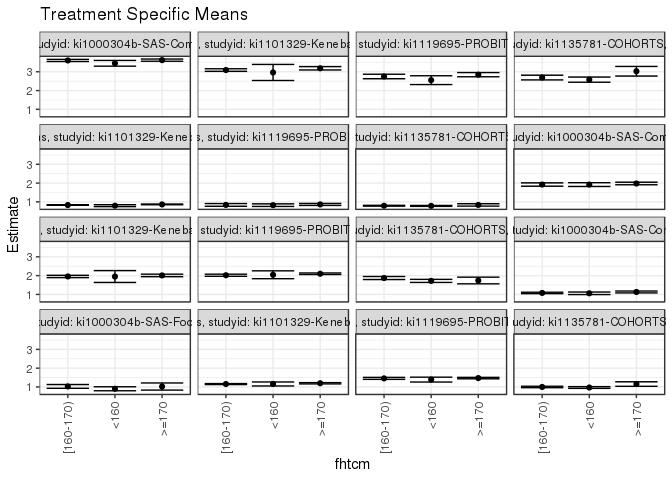

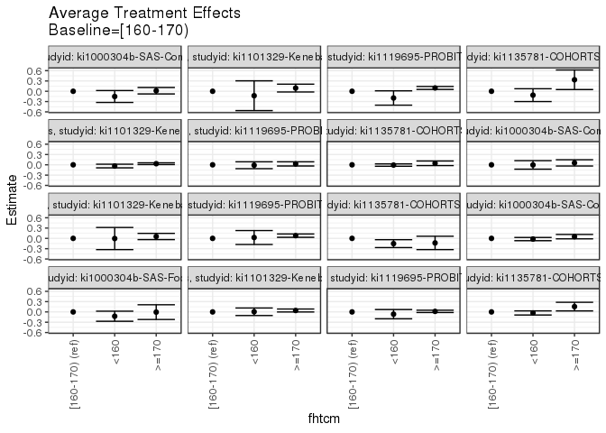

## Results Table

### Parameter: TSM

| agecat | studyid | country | intervention_level | baseline_level | estimate | ci_lower | ci_upper |
| --- | --- | --- | --- | --- | --- | --- | --- |
| 0-3 months | ki1000304b-SAS-CompFeed | INDIA | [160-170) | NA | 3.6033278 | 3.5466867 | 3.6599689 |
| 0-3 months | ki1000304b-SAS-CompFeed | INDIA | <160 | NA | 3.4509665 | 3.2983143 | 3.6036187 |
| 0-3 months | ki1000304b-SAS-CompFeed | INDIA | >=170 | NA | 3.6191464 | 3.5610893 | 3.6772036 |
| 0-3 months | ki1101329-Keneba | GAMBIA | [160-170) | NA | 3.0921792 | 3.0233210 | 3.1610375 |
| 0-3 months | ki1101329-Keneba | GAMBIA | <160 | NA | 2.9626362 | 2.5346251 | 3.3906474 |
| 0-3 months | ki1101329-Keneba | GAMBIA | >=170 | NA | 3.1853707 | 3.0948686 | 3.2758728 |
| 0-3 months | ki1119695-PROBIT | BELARUS | [160-170) | NA | 2.7489591 | 2.6290440 | 2.8688742 |
| 0-3 months | ki1119695-PROBIT | BELARUS | <160 | NA | 2.5528705 | 2.3178064 | 2.7879346 |
| 0-3 months | ki1119695-PROBIT | BELARUS | >=170 | NA | 2.8455161 | 2.7330758 | 2.9579564 |
| 0-3 months | ki1135781-COHORTS | GUATEMALA | [160-170) | NA | 2.6925692 | 2.5673018 | 2.8178366 |
| 0-3 months | ki1135781-COHORTS | GUATEMALA | <160 | NA | 2.5795051 | 2.4415207 | 2.7174895 |
| 0-3 months | ki1135781-COHORTS | GUATEMALA | >=170 | NA | 3.0275882 | 2.7713471 | 3.2838293 |
| 3-6 months | ki1000304b-SAS-CompFeed | INDIA | [160-170) | NA | 1.9228678 | 1.8337234 | 2.0120121 |
| 3-6 months | ki1000304b-SAS-CompFeed | INDIA | <160 | NA | 1.9201328 | 1.8203632 | 2.0199025 |
| 3-6 months | ki1000304b-SAS-CompFeed | INDIA | >=170 | NA | 1.9787776 | 1.9102423 | 2.0473129 |
| 3-6 months | ki1101329-Keneba | GAMBIA | [160-170) | NA | 1.9561797 | 1.8949234 | 2.0174359 |
| 3-6 months | ki1101329-Keneba | GAMBIA | <160 | NA | 1.9513970 | 1.6353274 | 2.2674666 |
| 3-6 months | ki1101329-Keneba | GAMBIA | >=170 | NA | 2.0108751 | 1.9441286 | 2.0776216 |
| 3-6 months | ki1119695-PROBIT | BELARUS | [160-170) | NA | 2.0211525 | 1.9638945 | 2.0784106 |
| 3-6 months | ki1119695-PROBIT | BELARUS | <160 | NA | 2.0460180 | 1.8362703 | 2.2557656 |
| 3-6 months | ki1119695-PROBIT | BELARUS | >=170 | NA | 2.1007389 | 2.0591394 | 2.1423383 |
| 3-6 months | ki1135781-COHORTS | GUATEMALA | [160-170) | NA | 1.8726511 | 1.7920273 | 1.9532750 |
| 3-6 months | ki1135781-COHORTS | GUATEMALA | <160 | NA | 1.7198005 | 1.6378350 | 1.8017660 |
| 3-6 months | ki1135781-COHORTS | GUATEMALA | >=170 | NA | 1.7400858 | 1.5633073 | 1.9168644 |
| 6-12 months | ki1000304b-SAS-CompFeed | INDIA | [160-170) | NA | 1.0789514 | 1.0420587 | 1.1158440 |
| 6-12 months | ki1000304b-SAS-CompFeed | INDIA | <160 | NA | 1.0586939 | 0.9908011 | 1.1265868 |
| 6-12 months | ki1000304b-SAS-CompFeed | INDIA | >=170 | NA | 1.1293259 | 1.0788106 | 1.1798413 |
| 6-12 months | ki1000304b-SAS-FoodSuppl | INDIA | [160-170) | NA | 1.0279267 | 0.9274765 | 1.1283769 |
| 6-12 months | ki1000304b-SAS-FoodSuppl | INDIA | <160 | NA | 0.9027195 | 0.7958087 | 1.0096304 |
| 6-12 months | ki1000304b-SAS-FoodSuppl | INDIA | >=170 | NA | 1.0222137 | 0.8320525 | 1.2123750 |
| 6-12 months | ki1101329-Keneba | GAMBIA | [160-170) | NA | 1.1545693 | 1.1283357 | 1.1808029 |
| 6-12 months | ki1101329-Keneba | GAMBIA | <160 | NA | 1.1591858 | 1.0526442 | 1.2657275 |
| 6-12 months | ki1101329-Keneba | GAMBIA | >=170 | NA | 1.1961761 | 1.1621274 | 1.2302249 |
| 6-12 months | ki1119695-PROBIT | BELARUS | [160-170) | NA | 1.4557045 | 1.4026751 | 1.5087338 |
| 6-12 months | ki1119695-PROBIT | BELARUS | <160 | NA | 1.3904681 | 1.2605038 | 1.5204324 |
| 6-12 months | ki1119695-PROBIT | BELARUS | >=170 | NA | 1.4719420 | 1.4332988 | 1.5105852 |
| 6-12 months | ki1135781-COHORTS | GUATEMALA | [160-170) | NA | 0.9993855 | 0.9603083 | 1.0384627 |
| 6-12 months | ki1135781-COHORTS | GUATEMALA | <160 | NA | 0.9695588 | 0.9241835 | 1.0149341 |
| 6-12 months | ki1135781-COHORTS | GUATEMALA | >=170 | NA | 1.1546139 | 1.0351772 | 1.2740505 |
| 12-24 months | ki1101329-Keneba | GAMBIA | [160-170) | NA | 0.8317919 | 0.8159280 | 0.8476559 |
| 12-24 months | ki1101329-Keneba | GAMBIA | <160 | NA | 0.7963109 | 0.7459205 | 0.8467014 |
| 12-24 months | ki1101329-Keneba | GAMBIA | >=170 | NA | 0.8642803 | 0.8446411 | 0.8839194 |
| 12-24 months | ki1119695-PROBIT | BELARUS | [160-170) | NA | 0.8371765 | 0.7649231 | 0.9094299 |
| 12-24 months | ki1119695-PROBIT | BELARUS | <160 | NA | 0.8251266 | 0.7570004 | 0.8932529 |
| 12-24 months | ki1119695-PROBIT | BELARUS | >=170 | NA | 0.8640465 | 0.8116883 | 0.9164046 |
| 12-24 months | ki1135781-COHORTS | GUATEMALA | [160-170) | NA | 0.7932741 | 0.7698285 | 0.8167196 |
| 12-24 months | ki1135781-COHORTS | GUATEMALA | <160 | NA | 0.7858493 | 0.7609414 | 0.8107573 |
| 12-24 months | ki1135781-COHORTS | GUATEMALA | >=170 | NA | 0.8378083 | 0.7749680 | 0.9006486 |

### Parameter: E(Y)

| agecat | studyid | country | intervention_level | baseline_level | estimate | ci_lower | ci_upper |
| --- | --- | --- | --- | --- | --- | --- | --- |
| 0-3 months | ki1000304b-SAS-CompFeed | INDIA | NA | NA | 3.5844413 | 3.5457307 | 3.6231519 |
| 0-3 months | ki1101329-Keneba | GAMBIA | NA | NA | 3.1289757 | 3.0738379 | 3.1841134 |
| 0-3 months | ki1119695-PROBIT | BELARUS | NA | NA | 2.8334708 | 2.7205961 | 2.9463455 |
| 0-3 months | ki1135781-COHORTS | GUATEMALA | NA | NA | 2.6646531 | 2.5748250 | 2.7544813 |
| 3-6 months | ki1000304b-SAS-CompFeed | INDIA | NA | NA | 1.9381168 | 1.8722991 | 2.0039344 |
| 3-6 months | ki1101329-Keneba | GAMBIA | NA | NA | 1.9794873 | 1.9347361 | 2.0242384 |
| 3-6 months | ki1119695-PROBIT | BELARUS | NA | NA | 2.0916969 | 2.0506004 | 2.1327933 |
| 3-6 months | ki1135781-COHORTS | GUATEMALA | NA | NA | 1.7979953 | 1.7423030 | 1.8536877 |
| 6-12 months | ki1000304b-SAS-CompFeed | INDIA | NA | NA | 1.0908364 | 1.0624756 | 1.1191972 |
| 6-12 months | ki1000304b-SAS-FoodSuppl | INDIA | NA | NA | 0.9947133 | 0.9228294 | 1.0665973 |
| 6-12 months | ki1101329-Keneba | GAMBIA | NA | NA | 1.1722791 | 1.1516434 | 1.1929147 |
| 6-12 months | ki1119695-PROBIT | BELARUS | NA | NA | 1.4698038 | 1.4307195 | 1.5088880 |
| 6-12 months | ki1135781-COHORTS | GUATEMALA | NA | NA | 0.9973638 | 0.9680912 | 1.0266364 |
| 12-24 months | ki1101329-Keneba | GAMBIA | NA | NA | 0.8443568 | 0.8321723 | 0.8565414 |
| 12-24 months | ki1119695-PROBIT | BELARUS | NA | NA | 0.8608646 | 0.8094654 | 0.9122639 |
| 12-24 months | ki1135781-COHORTS | GUATEMALA | NA | NA | 0.7934317 | 0.7769015 | 0.8099619 |

### Parameter: ATE

| agecat | studyid | country | intervention_level | baseline_level | estimate | ci_lower | ci_upper |
| --- | --- | --- | --- | --- | --- | --- | --- |
| 0-3 months | ki1000304b-SAS-CompFeed | INDIA | [160-170) | [160-170) | 0.0000000 | 0.0000000 | 0.0000000 |
| 0-3 months | ki1000304b-SAS-CompFeed | INDIA | <160 | [160-170) | -0.1523613 | -0.3254656 | 0.0207430 |
| 0-3 months | ki1000304b-SAS-CompFeed | INDIA | >=170 | [160-170) | 0.0158186 | -0.0780903 | 0.1097276 |
| 0-3 months | ki1101329-Keneba | GAMBIA | [160-170) | [160-170) | 0.0000000 | 0.0000000 | 0.0000000 |
| 0-3 months | ki1101329-Keneba | GAMBIA | <160 | [160-170) | -0.1295430 | -0.5630577 | 0.3039717 |
| 0-3 months | ki1101329-Keneba | GAMBIA | >=170 | [160-170) | 0.0931915 | -0.0205278 | 0.2069108 |
| 0-3 months | ki1119695-PROBIT | BELARUS | [160-170) | [160-170) | 0.0000000 | 0.0000000 | 0.0000000 |
| 0-3 months | ki1119695-PROBIT | BELARUS | <160 | [160-170) | -0.1960886 | -0.4042525 | 0.0120754 |
| 0-3 months | ki1119695-PROBIT | BELARUS | >=170 | [160-170) | 0.0965570 | 0.0534230 | 0.1396910 |
| 0-3 months | ki1135781-COHORTS | GUATEMALA | [160-170) | [160-170) | 0.0000000 | 0.0000000 | 0.0000000 |
| 0-3 months | ki1135781-COHORTS | GUATEMALA | <160 | [160-170) | -0.1130641 | -0.2994283 | 0.0733001 |
| 0-3 months | ki1135781-COHORTS | GUATEMALA | >=170 | [160-170) | 0.3350189 | 0.0497972 | 0.6202407 |
| 3-6 months | ki1000304b-SAS-CompFeed | INDIA | [160-170) | [160-170) | 0.0000000 | 0.0000000 | 0.0000000 |
| 3-6 months | ki1000304b-SAS-CompFeed | INDIA | <160 | [160-170) | -0.0027349 | -0.1267741 | 0.1213043 |
| 3-6 months | ki1000304b-SAS-CompFeed | INDIA | >=170 | [160-170) | 0.0559099 | -0.0354491 | 0.1472688 |
| 3-6 months | ki1101329-Keneba | GAMBIA | [160-170) | [160-170) | 0.0000000 | 0.0000000 | 0.0000000 |
| 3-6 months | ki1101329-Keneba | GAMBIA | <160 | [160-170) | -0.0047827 | -0.3267335 | 0.3171681 |
| 3-6 months | ki1101329-Keneba | GAMBIA | >=170 | [160-170) | 0.0546954 | -0.0358994 | 0.1452903 |
| 3-6 months | ki1119695-PROBIT | BELARUS | [160-170) | [160-170) | 0.0000000 | 0.0000000 | 0.0000000 |
| 3-6 months | ki1119695-PROBIT | BELARUS | <160 | [160-170) | 0.0248654 | -0.1786394 | 0.2283703 |
| 3-6 months | ki1119695-PROBIT | BELARUS | >=170 | [160-170) | 0.0795863 | 0.0308841 | 0.1282886 |
| 3-6 months | ki1135781-COHORTS | GUATEMALA | [160-170) | [160-170) | 0.0000000 | 0.0000000 | 0.0000000 |
| 3-6 months | ki1135781-COHORTS | GUATEMALA | <160 | [160-170) | -0.1528506 | -0.2678226 | -0.0378787 |
| 3-6 months | ki1135781-COHORTS | GUATEMALA | >=170 | [160-170) | -0.1325653 | -0.3268611 | 0.0617305 |
| 6-12 months | ki1000304b-SAS-CompFeed | INDIA | [160-170) | [160-170) | 0.0000000 | 0.0000000 | 0.0000000 |
| 6-12 months | ki1000304b-SAS-CompFeed | INDIA | <160 | [160-170) | -0.0202574 | -0.0669405 | 0.0264256 |
| 6-12 months | ki1000304b-SAS-CompFeed | INDIA | >=170 | [160-170) | 0.0503746 | -0.0132105 | 0.1139597 |
| 6-12 months | ki1000304b-SAS-FoodSuppl | INDIA | [160-170) | [160-170) | 0.0000000 | 0.0000000 | 0.0000000 |
| 6-12 months | ki1000304b-SAS-FoodSuppl | INDIA | <160 | [160-170) | -0.1252071 | -0.2719047 | 0.0214904 |
| 6-12 months | ki1000304b-SAS-FoodSuppl | INDIA | >=170 | [160-170) | -0.0057129 | -0.2207747 | 0.2093488 |
| 6-12 months | ki1101329-Keneba | GAMBIA | [160-170) | [160-170) | 0.0000000 | 0.0000000 | 0.0000000 |
| 6-12 months | ki1101329-Keneba | GAMBIA | <160 | [160-170) | 0.0046166 | -0.1051073 | 0.1143404 |
| 6-12 months | ki1101329-Keneba | GAMBIA | >=170 | [160-170) | 0.0416069 | -0.0013759 | 0.0845897 |
| 6-12 months | ki1119695-PROBIT | BELARUS | [160-170) | [160-170) | 0.0000000 | 0.0000000 | 0.0000000 |
| 6-12 months | ki1119695-PROBIT | BELARUS | <160 | [160-170) | -0.0652364 | -0.1998788 | 0.0694060 |
| 6-12 months | ki1119695-PROBIT | BELARUS | >=170 | [160-170) | 0.0162376 | -0.0172954 | 0.0497705 |
| 6-12 months | ki1135781-COHORTS | GUATEMALA | [160-170) | [160-170) | 0.0000000 | 0.0000000 | 0.0000000 |
| 6-12 months | ki1135781-COHORTS | GUATEMALA | <160 | [160-170) | -0.0298267 | -0.0897095 | 0.0300561 |
| 6-12 months | ki1135781-COHORTS | GUATEMALA | >=170 | [160-170) | 0.1552284 | 0.0295616 | 0.2808952 |
| 12-24 months | ki1101329-Keneba | GAMBIA | [160-170) | [160-170) | 0.0000000 | 0.0000000 | 0.0000000 |
| 12-24 months | ki1101329-Keneba | GAMBIA | <160 | [160-170) | -0.0354810 | -0.0883096 | 0.0173476 |
| 12-24 months | ki1101329-Keneba | GAMBIA | >=170 | [160-170) | 0.0324884 | 0.0072423 | 0.0577344 |
| 12-24 months | ki1119695-PROBIT | BELARUS | [160-170) | [160-170) | 0.0000000 | 0.0000000 | 0.0000000 |
| 12-24 months | ki1119695-PROBIT | BELARUS | <160 | [160-170) | -0.0120499 | -0.1121102 | 0.0880103 |
| 12-24 months | ki1119695-PROBIT | BELARUS | >=170 | [160-170) | 0.0268699 | -0.0337723 | 0.0875121 |
| 12-24 months | ki1135781-COHORTS | GUATEMALA | [160-170) | [160-170) | 0.0000000 | 0.0000000 | 0.0000000 |
| 12-24 months | ki1135781-COHORTS | GUATEMALA | <160 | [160-170) | -0.0074247 | -0.0416315 | 0.0267820 |
| 12-24 months | ki1135781-COHORTS | GUATEMALA | >=170 | [160-170) | 0.0445342 | -0.0225374 | 0.1116059 |